**CS4132 Data Analytics**

# Gaming during COVID-19 by Alexis Henri Milesi

Important Note: Please keep your report concise and relevant (i.e. show only relevant steps and visualizations used to answer your research questions).

# Table of Content

Motivation & Background  
Summary of Research Questions & Results  
Methodology  
Data Acquisition  
Data Cleaning  
Exploratory Data Analysis  
Results Findings & Conclusion

# Motivation and Background

Give an overview of the project, motivation, background and goals.

Gaming as an industry has been growing over the years and has certainly grown exponentially at the height of the pandemic, with games like "Animal Crossing: New Horizons" and "Among Us" booming in popularity. Hence, I would like to study the overall amount of players it brought to the gaming industry.

# Summary of Research Questions & Results

Repeat your research questions in a numbered list. After each research question, clearly state the answer/conclusion you determined. Do not give details or justifications yet — just the answer

# 1. How has gaming growth changed during to the pandemic?

Throughout the pandemic, people have been stuck at homes. I would like to find out whether the pandemic has had an impact on the gaming industry in general.

- Yes, gaming has definitely grown over the pandemic. With a spike increase during 2020 that continues to the current day

# 2. Does the number of COVID-19 measures implemented correlate with the player count of various games?

By comparing the number of COVID-19 measures implemented around the world to the sum player count of online games, I will be able to observe their potential relationship.

# 3. How does the growth vary between genres of games during the pandemic?

Different games address different needs of individuals. Hence the pandemic may have impacted certain types of games more than others. By comparing the player count of different game genres, I can identify what people were looking for during the pandemic, whether it’s a social experience from a multiplayer game, the desire for competitiveness in strategy games, or solitary experiences from a singleplayer game.

- Genres which provide an alternate reality for people to live in, like Adventure, RPG etc, relaxing games or competitive games grew tremendously during the pandemic. Surprisingly, massively multiplayer games did not rise significantly during the pandemic

# 4. How has free-to-play games been impacted differently from paid games during the pandemic?

Free-to-play have always appealed to a larger audience, due to its easy accessibility. Comparing them with paid games could help us understand whether people are more willing to spend money on video games during the pandemic. I will also compare games with different price ranges to find out how much people are willing to spend on video games during the periods which they seldom venture outside.

- Indeed, free games player count has increased during the pandemic. Paid games did also increase, with more expensive games increasing later in the time.

# Dataset

Numbered list of dataset (with downloadable links) and a brief but clear description of each dataset used. Draw reference to the numbering when describing (data cleaning and analysis).

1. https://www.acaps.org/covid-19-government-measures-dataset#:~:text=The%20COVID%2D19%20Government%20Measures,Social%20distancing This data contains responses of various countries due to COVID-19
2. https://steamspy.com/api.php This API allows me to receive data about games. This was the main way to get games onto the dataset, as well as give useful data about them such as price, genres, and positive and negative reviews.
3. https://steamcharts.com This website was webscrabbed in order to get the monthly average concurrent players.

# Methodology

You should demonstrate the data science life cycle here (from data acquisition to cleaning to EDA and analysis etc).

# 1. How has gaming growth changed due to the pandemic?

# 2. Does the number of COVID-19 measures correlate with the player count of various games?

I will compare the sum of player count of the various games to the COVID-19 measures around the world by plotting a correlation graph. This would allow me to find the relationship with COVID-19 measures implemented against the number of people playing video games.

# 3. How does the growth vary between genres of games during the pandemic?

First, I will collate all the games into various categories using their genre on Steam. For example, multiplayer, singleplayer, RPG (Roleplaying Games), Sandbox etc. I will plot a boxplot of the average player count of each game genre to see the distribution of games with players across each genre, and plot a line graph to see the trend of each genre

# 4. How has free-to-play games been impacted differently from paid games during the pandemic?

First, I will collate all the games into different categories; free-to-play, \$0.01-\\$4.99, \$5.00-\\$9.99, \$10.00-\\$19.99, \$20.00-\\$39.99, \$39.99-\\$59.99, >=\$60. I will plot a boxplot of the average player count of each price range to see the distribution of games with players across each price range, and plot a line graph to see the trend of each price range

## Data Acquisition

Display the data which will be used in the project. The data should be saved in .xlsx or .csv format to be submitted with the project. If webscraping has been done to obtain your data, save your webscraping code in another jupyter notebook as appendix to be submitted separately from the report. Import and display each dataset in a dataframe. For each dataset, give a brief overview of the data it contains, and explain the meaning of columns that are relevant to the project.

```python
import pandas as pd
import numpy as np
import matplotlib.pyplot as plt
import seaborn as sns
apps=pd.read_csv('app_list.csv')
measures=pd.read_excel('Government_Measures_COVID.xlsx', sheet_name="Dataset")
```

Column Description

appid - AppId of the game as listed in steam.

name - Name of the game

developer - Developer of the game

publisher - Publisher of the game

price - Price of the game

positive - number of positive reviews of the game

negative - number of negative reviews of the game

Genre - genre of the game that is listed by the developer/publisher

The rest of the columns contain data of the monthly concurrent players from July 2012 to August 2022

```python
apps
```

|  | appid | name | developer | publisher | price | positive | negative | Genre | June 2017 | July 2017 | ... | November 2021 | December 2021 | January 2022 | February 2022 | March 2022 | April 2022 | May 2022 | June 2022 | July 2022 | August 2022 |
| --- | --- | --- | --- | --- | --- | --- | --- | --- | --- | --- | --- | --- | --- | --- | --- | --- | --- | --- | --- | --- | --- |
| 0 | 377000 | AnyTime Organizer Deluxe 15 | Individual Software | Individual Software | 0.0 | 0 | 1 | Education | 0.1 | 0.0 | ... | NaN | NaN | NaN | NaN | NaN | NaN | NaN | NaN | NaN | NaN |
| 1 | 377010 | Easy Spanish Platinum | Individual Software | Individual Software | 3999.0 | 0 | 1 | Education | NaN | NaN | ... | NaN | NaN | NaN | NaN | NaN | NaN | NaN | NaN | NaN | NaN |
| 2 | 398950 | The End of an Age: Fading Remnants | Poetic Justice Studios | Poetic Justice Studios | 499.0 | 0 | 1 | RPG | NaN | NaN | ... | NaN | NaN | NaN | NaN | NaN | NaN | NaN | NaN | NaN | NaN |
| 3 | 413350 | Daydream Blue | RalphVR | RalphVR | 499.0 | 0 | 2 | Adventure,Casual,Indie | NaN | NaN | ... | NaN | NaN | NaN | NaN | NaN | NaN | NaN | NaN | NaN | NaN |
| 4 | 441850 | ScriptVOX Studio | Screaming Bee | Screaming Bee | 2999.0 | 0 | 1 | Animation & Modeling,Audio Production,Software... | NaN | NaN | ... | NaN | NaN | NaN | NaN | NaN | NaN | NaN | NaN | NaN | NaN |
| ... | ... | ... | ... | ... | ... | ... | ... | ... | ... | ... | ... | ... | ... | ... | ... | ... | ... | ... | ... | ... | ... |
| 42695 | 2101630 | Coins Collector Sport Car | Atomic Fabrik, Cristian Manolachi | Atomic Fabrik, Cristian Manolachi | 499.0 | 0 | 1 | Casual,Indie,Racing,Simulation | NaN | NaN | ... | NaN | NaN | NaN | NaN | NaN | NaN | NaN | NaN | NaN | NaN |
| 42696 | 2104700 | Bubble Shooter | xxGame | xxGame | 499.0 | 0 | 1 | Casual,Indie | NaN | NaN | ... | NaN | NaN | NaN | NaN | NaN | NaN | NaN | NaN | NaN | NaN |
| 42697 | 2112570 | Zombies TD | IVS96 | IVS96 | 199.0 | 0 | 1 | Casual,Strategy | NaN | NaN | ... | NaN | NaN | NaN | NaN | NaN | NaN | NaN | NaN | NaN | NaN |
| 42698 | 2114090 | Goetita: Turn-based City | AigoiA | Oidoi Company | 899.0 | 0 | 2 | Indie,Strategy,Early Access | NaN | NaN | ... | NaN | NaN | NaN | NaN | NaN | NaN | NaN | NaN | NaN | NaN |
| 42699 | 2122590 | Call of Dusk | Luiz Otávio da Silva | Luiz Otávio da Silva | 1619.0 | 0 | 1 | Action,Indie,Massively Multiplayer | NaN | NaN | ... | NaN | NaN | NaN | NaN | NaN | NaN | NaN | NaN | NaN | NaN |

42700 rows × 130 columns

Column Description

ID- ID of the entry of lockdown

ISO - ISO code of the country

COUNTRY - Country that enacted the COVID-19 measure

REGION - Region of the country

ADMIN_LEVEL_NAME - Country/State/City/Organisation which enacted the measure

PCODE - This column is empty

LOG_TYPE - Shows whether its a phase out measure or the introduction/extension of a measure

CATEGORY - Shows the category of the measure. (E.g. Movement restrictions, Economic Measures, Social distancing)

TARGETED_POP_GROUP - Shows whether the measure was targeted towards a specific population group

COMMENTS - Describes in detail what was done

NON_COMPLIANCE - Shows the consequences if the population do not comply with the measure

DATE_IMPLEMENTED - The date the measure was implemented

SOURCE - Source of the news of the measure being implemented

SOURCE_TYPE - Where the source announced the measure.

LINK - Link of the source

ENTRY_DATE - Date of which the entry of the dataset was made.

```python
measures
```

|  | ID | ISO | COUNTRY | REGION | ADMIN_LEVEL_NAME | PCODE | LOG_TYPE | CATEGORY | MEASURE | TARGETED_POP_GROUP | COMMENTS | NON_COMPLIANCE | DATE_IMPLEMENTED | SOURCE | SOURCE_TYPE | LINK | ENTRY_DATE | Alternative source |
| --- | --- | --- | --- | --- | --- | --- | --- | --- | --- | --- | --- | --- | --- | --- | --- | --- | --- | --- |
| 0 | 4245 | AFG | Afghanistan | Asia | NaN | NaN | Introduction / extension of measures | Public health measures | Awareness campaigns | NaN | MoPH begins announcements on their facebook to... | NaN | 2020-01-24 | Afghanistan MoPH | Government | https://www.facebook.com/af.moph/posts/1005130... | 2020-04-07 | NaN |
| 1 | 4246 | AFG | Afghanistan | Asia | NaN | NaN | Introduction / extension of measures | Public health measures | Health screenings in airports and border cross... | checked | Health teams at airports will check passengers... | NaN | 2020-01-26 | Afghanistan MoPH | Government | https://www.facebook.com/af.moph/posts/1006458... | 2020-04-07 | NaN |
| 2 | 4247 | AFG | Afghanistan | Asia | NaN | NaN | Introduction / extension of measures | Movement restrictions | International flights suspension | checked | Flights to China are suspended. | NaN | 2020-01-27 | Afghanistan MoPH | Government | https://www.facebook.com/af.moph/photos/a.4625... | 2020-04-07 | NaN |
| 3 | 4248 | AFG | Afghanistan | Asia | NaN | NaN | Introduction / extension of measures | Public health measures | Health screenings in airports and border cross... | NaN | Health screenings of all passengers at airports. | NaN | 2020-01-27 | Afghanistan MoPH | Government | https://www.facebook.com/af.moph/photos/a.4625... | 2020-04-07 | NaN |
| 4 | 23 | AFG | Afghanistan | Asia | NaN | NaN | Introduction / extension of measures | Movement restrictions | Border checks | checked | All China and Iran nationals | NaN | 2020-02-01 | US Embassy | Government | https://af.usembassy.gov/covid-19-information/ | 2020-03-14 | NaN |
| ... | ... | ... | ... | ... | ... | ... | ... | ... | ... | ... | ... | ... | ... | ... | ... | ... | ... | ... |
| 23918 | 13724 | ZWE | Zimbabwe | Africa | NaN | NaN | Introduction / extension of measures | Movement restrictions | Surveillance and monitoring | checked | Identification/travel documents of returness w... | Not available | 2020-06-09 | Ministry of Information | Social media | https://twitter.com/MinOfInfoZW/status/1270378... | 2020-06-13 | NaN |
| 23919 | 14735 | ZWE | Zimbabwe | Africa | NaN | NaN | Phase-out measure | Social distancing | Closure of businesses and public services | checked | Safari Operators for local hunting only and Na... | Not applicable | 2020-06-30 | Ministry of Information | Social media | https://twitter.com/MinOfInfoZW/status/1278043... | 2020-07-03 | NaN |
| 23920 | 14734 | ZWE | Zimbabwe | Africa | NaN | NaN | Phase-out measure | Social distancing | Closure of businesses and public services | checked | Restaurants now allowed to serve sit-in meals ... | Not applicable | 2020-06-30 | Ministry of Information | Social media | https://twitter.com/MinOfInfoZW/status/1278043... | 2020-07-03 | NaN |
| 23921 | 13723 | ZWE | Zimbabwe | Africa | NaN | NaN | Phase-out measure | Social distancing | Schools closure | NaN | the re-opening of schools be moved from the pr... | Not applicable | 2020-07-28 | Ministry of Information | Social media | https://twitter.com/MinOfInfoZW/status/1270378... | 2020-06-13 | NaN |
| 23922 | 138074 | ZWE | Zimbabwe | Africa | NaN | NaN | Introduction / extension of measures | Public health measures | Health screenings in airports and border cross... | checked | Passengers will undergo temperature checks at ... | Not Available | 2020-10-01 | Emirates | Media | https://www.emirates.com/za/english/help/faqs/... | 2020-10-30 | NaN |

23923 rows × 18 columns

## Data Cleaning

For data cleaning, be clear in which dataset (or variables) are used, what has been done for missing data, how was merging performed, explanation of data transformation (if any). If data is calculated or summarized from the raw dataset, explain the rationale and steps clearly.

```python
apps=apps.drop_duplicates()
```

```python
apps.iloc[:,0:8].info()
```

```
<class 'pandas.core.frame.DataFrame'>
Int64Index: 39014 entries, 0 to 42699
Data columns (total 8 columns):
 #   Column     Non-Null Count  Dtype
---  ------     --------------  -----
 0   appid      39014 non-null  int64
 1   name       39006 non-null  object
 2   developer  38883 non-null  object
 3   publisher  38940 non-null  object
 4   price      39010 non-null  float64
 5   positive   39014 non-null  int64
 6   negative   39014 non-null  int64
 7   Genre      38577 non-null  object
dtypes: float64(1), int64(3), object(4)
memory usage: 2.7+ MB
```

Since the parts of the dataset which is nil is nil at random, I will remove the nil entries from the dataset and will not impact the result significantly. However, for the dates, nil simply means the game either was taken down or wasn't released yet, and i will not be dropping them.

```python
apps=apps[np.logical_not(apps.iloc[:,0:8].isna().any(axis=1))]
apps
```

|  | appid | name | developer | publisher | price | positive | negative | Genre | June 2017 | July 2017 | ... | November 2021 | December 2021 | January 2022 | February 2022 | March 2022 | April 2022 | May 2022 | June 2022 | July 2022 | August 2022 |
| --- | --- | --- | --- | --- | --- | --- | --- | --- | --- | --- | --- | --- | --- | --- | --- | --- | --- | --- | --- | --- | --- |
| 0 | 377000 | AnyTime Organizer Deluxe 15 | Individual Software | Individual Software | 0.0 | 0 | 1 | Education | 0.1 | 0.0 | ... | NaN | NaN | NaN | NaN | NaN | NaN | NaN | NaN | NaN | NaN |
| 1 | 377010 | Easy Spanish Platinum | Individual Software | Individual Software | 3999.0 | 0 | 1 | Education | NaN | NaN | ... | NaN | NaN | NaN | NaN | NaN | NaN | NaN | NaN | NaN | NaN |
| 2 | 398950 | The End of an Age: Fading Remnants | Poetic Justice Studios | Poetic Justice Studios | 499.0 | 0 | 1 | RPG | NaN | NaN | ... | NaN | NaN | NaN | NaN | NaN | NaN | NaN | NaN | NaN | NaN |
| 3 | 413350 | Daydream Blue | RalphVR | RalphVR | 499.0 | 0 | 2 | Adventure,Casual,Indie | NaN | NaN | ... | NaN | NaN | NaN | NaN | NaN | NaN | NaN | NaN | NaN | NaN |
| 4 | 441850 | ScriptVOX Studio | Screaming Bee | Screaming Bee | 2999.0 | 0 | 1 | Animation & Modeling,Audio Production,Software... | NaN | NaN | ... | NaN | NaN | NaN | NaN | NaN | NaN | NaN | NaN | NaN | NaN |
| ... | ... | ... | ... | ... | ... | ... | ... | ... | ... | ... | ... | ... | ... | ... | ... | ... | ... | ... | ... | ... | ... |
| 42695 | 2101630 | Coins Collector Sport Car | Atomic Fabrik, Cristian Manolachi | Atomic Fabrik, Cristian Manolachi | 499.0 | 0 | 1 | Casual,Indie,Racing,Simulation | NaN | NaN | ... | NaN | NaN | NaN | NaN | NaN | NaN | NaN | NaN | NaN | NaN |
| 42696 | 2104700 | Bubble Shooter | xxGame | xxGame | 499.0 | 0 | 1 | Casual,Indie | NaN | NaN | ... | NaN | NaN | NaN | NaN | NaN | NaN | NaN | NaN | NaN | NaN |
| 42697 | 2112570 | Zombies TD | IVS96 | IVS96 | 199.0 | 0 | 1 | Casual,Strategy | NaN | NaN | ... | NaN | NaN | NaN | NaN | NaN | NaN | NaN | NaN | NaN | NaN |
| 42698 | 2114090 | Goetita: Turn-based City | AigoiA | Oidoi Company | 899.0 | 0 | 2 | Indie,Strategy,Early Access | NaN | NaN | ... | NaN | NaN | NaN | NaN | NaN | NaN | NaN | NaN | NaN | NaN |
| 42699 | 2122590 | Call of Dusk | Luiz Otávio da Silva | Luiz Otávio da Silva | 1619.0 | 0 | 1 | Action,Indie,Massively Multiplayer | NaN | NaN | ... | NaN | NaN | NaN | NaN | NaN | NaN | NaN | NaN | NaN | NaN |

38437 rows × 130 columns

Since the dates are not ordered correctly, I shall make it as such. Also, since some columns are not necessary from this dataset, I shall also remove them

```python
apps.columns[8:108]
#As shown, dates are not put in the correct order
```

```
Index(['June 2017', 'July 2017', 'August 2017', 'September 2017',
       'November 2017', 'December 2017', 'January 2018', 'February 2018',
       'March 2018', 'April 2018', 'May 2018', 'August 2018', 'November 2018',
       'April 2019', 'May 2019', 'August 2019', 'September 2015', 'April 2016',
       'December 2016', 'July 2019', 'March 2017', 'April 2017', 'May 2017',
       'October 2017', 'June 2018', 'July 2018', 'September 2018',
       'October 2018', 'December 2018', 'January 2019', 'March 2019',
       'February 2019', 'June 2019', 'July 2012', 'August 2012',
       'September 2012', 'October 2012', 'November 2012', 'December 2012',
       'January 2013', 'February 2013', 'March 2013', 'April 2013', 'May 2013',
       'June 2013', 'July 2013', 'August 2013', 'September 2013',
       'October 2013', 'November 2013', 'December 2013', 'January 2014',
       'February 2014', 'March 2014', 'April 2014', 'May 2014', 'June 2014',
       'July 2014', 'August 2014', 'September 2014', 'October 2014',
       'November 2014', 'December 2014', 'January 2015', 'February 2015',
       'March 2015', 'April 2015', 'May 2015', 'June 2015', 'July 2015',
       'August 2015', 'October 2015', 'November 2015', 'December 2015',
       'January 2016', 'February 2016', 'March 2016', 'May 2016', 'June 2016',
       'July 2016', 'August 2016', 'September 2016', 'October 2016',
       'November 2016', 'January 2017', 'February 2017', 'September 2019',
       'October 2019', 'November 2019', 'December 2019', 'January 2020',
       'February 2020', 'March 2020', 'April 2020', 'May 2020', 'June 2020',
       'July 2020', 'August 2020', 'September 2020', 'October 2020'],
      dtype='object')
```

```python
#reordering columns and getting rid of the variables that aren't necessary
apps=apps[['name', 'developer', 'publisher', 'price', 'Genre',
           "July 2012", "August 2012", "September 2012", "October 2012", "November 2012", "December 2012", "January 2013",
           "February 2013", "March 2013", "April 2013", "May 2013", "June 2013", "July 2013", "August 2013", "September 2013",
           "October 2013", "November 2013", "December 2013", "January 2014","February 2014", "March 2014", "April 2014",
           "May 2014", "June 2014", "July 2014", "August 2014", "September 2014", "October 2014", "November 2014",
           "December 2014", "January 2015", "February 2015", "March 2015", "April 2015", "May 2015", "June 2015", "July 2015",
           "August 2015", "September 2015", "October 2015", "November 2015", "December 2015", "January 2016","February 2016",
           "March 2016", "April 2016", "May 2016", "June 2016", "July 2016", "August 2016", "September 2016", "October 2016",
           "November 2016", "December 2016", "January 2017","February 2017", "March 2017", "April 2017", "May 2017","June 2017",
           "July 2017", "August 2017", "September 2017", "October 2017", "November 2017", "December 2017", "January 2018",
           "February 2018", "March 2018", "April 2018", "May 2018", "June 2018", "July 2018", "August 2018", "September 2018",
           "October 2018", "November 2018", "December 2018", "January 2019","February 2019", "March 2019", "April 2019",
           "May 2019", "June 2019", "July 2019", "August 2019", "September 2019", "October 2019", "November 2019", "December 2019",
           "January 2020", "February 2020", "March 2020", "April 2020", "May 2020", "June 2020", "July 2020", "August 2020",
           "September 2020", "October 2020", "November 2020", "December 2020", "January 2021","February 2021", "March 2021",
           "April 2021", "May 2021", "June 2021", "July 2021", "August 2021", "September 2021", "October 2021", "November 2021",
           "December 2021", "January 2022","February 2022", "March 2022", "April 2022", "May 2022", "June 2022", "July 2022",
           "August 2022"]]
apps
```

|  | name | developer | publisher | price | Genre | July 2012 | August 2012 | September 2012 | October 2012 | November 2012 | ... | November 2021 | December 2021 | January 2022 | February 2022 | March 2022 | April 2022 | May 2022 | June 2022 | July 2022 | August 2022 |
| --- | --- | --- | --- | --- | --- | --- | --- | --- | --- | --- | --- | --- | --- | --- | --- | --- | --- | --- | --- | --- | --- |
| 0 | AnyTime Organizer Deluxe 15 | Individual Software | Individual Software | 0.0 | Education | NaN | NaN | NaN | NaN | NaN | ... | NaN | NaN | NaN | NaN | NaN | NaN | NaN | NaN | NaN | NaN |
| 1 | Easy Spanish Platinum | Individual Software | Individual Software | 3999.0 | Education | NaN | NaN | NaN | NaN | NaN | ... | NaN | NaN | NaN | NaN | NaN | NaN | NaN | NaN | NaN | NaN |
| 2 | The End of an Age: Fading Remnants | Poetic Justice Studios | Poetic Justice Studios | 499.0 | RPG | NaN | NaN | NaN | NaN | NaN | ... | NaN | NaN | NaN | NaN | NaN | NaN | NaN | NaN | NaN | NaN |
| 3 | Daydream Blue | RalphVR | RalphVR | 499.0 | Adventure,Casual,Indie | NaN | NaN | NaN | NaN | NaN | ... | NaN | NaN | NaN | NaN | NaN | NaN | NaN | NaN | NaN | NaN |
| 4 | ScriptVOX Studio | Screaming Bee | Screaming Bee | 2999.0 | Animation & Modeling,Audio Production,Software... | NaN | NaN | NaN | NaN | NaN | ... | NaN | NaN | NaN | NaN | NaN | NaN | NaN | NaN | NaN | NaN |
| ... | ... | ... | ... | ... | ... | ... | ... | ... | ... | ... | ... | ... | ... | ... | ... | ... | ... | ... | ... | ... | ... |
| 42695 | Coins Collector Sport Car | Atomic Fabrik, Cristian Manolachi | Atomic Fabrik, Cristian Manolachi | 499.0 | Casual,Indie,Racing,Simulation | NaN | NaN | NaN | NaN | NaN | ... | NaN | NaN | NaN | NaN | NaN | NaN | NaN | NaN | NaN | NaN |
| 42696 | Bubble Shooter | xxGame | xxGame | 499.0 | Casual,Indie | NaN | NaN | NaN | NaN | NaN | ... | NaN | NaN | NaN | NaN | NaN | NaN | NaN | NaN | NaN | NaN |
| 42697 | Zombies TD | IVS96 | IVS96 | 199.0 | Casual,Strategy | NaN | NaN | NaN | NaN | NaN | ... | NaN | NaN | NaN | NaN | NaN | NaN | NaN | NaN | NaN | NaN |
| 42698 | Goetita: Turn-based City | AigoiA | Oidoi Company | 899.0 | Indie,Strategy,Early Access | NaN | NaN | NaN | NaN | NaN | ... | NaN | NaN | NaN | NaN | NaN | NaN | NaN | NaN | NaN | NaN |
| 42699 | Call of Dusk | Luiz Otávio da Silva | Luiz Otávio da Silva | 1619.0 | Action,Indie,Massively Multiplayer | NaN | NaN | NaN | NaN | NaN | ... | NaN | NaN | NaN | NaN | NaN | NaN | NaN | NaN | NaN | NaN |

38437 rows × 127 columns

There are also some apps on this dataset which are not actually games, i shall look at the genre to find out whether they are actually games.

```python
apps=apps[np.logical_not((apps.Genre.str.contains("网络出版")) |(apps.Genre.str.contains("设计和插画")) |(apps.Genre.str.contains("Animation & Modeling")) |(apps.Genre.str.contains("Education")) |(apps.Genre.str.contains("Photo Editing")) |(apps.Genre.str.contains("Video Production")) |(apps.Genre.str.contains("Accounting")) |(apps.Genre.str.contains("Web Publishing")) |(apps.Genre.str.contains("Utilities")) |(apps.Genre.str.contains("Game Development")) |(apps.Genre.str.contains("Design & Illustration")) |(apps.Genre.str.contains("Software Training")) | (apps.Genre.str.contains("Audio Production")))]
apps
```

|  | name | developer | publisher | price | Genre | July 2012 | August 2012 | September 2012 | October 2012 | November 2012 | ... | November 2021 | December 2021 | January 2022 | February 2022 | March 2022 | April 2022 | May 2022 | June 2022 | July 2022 | August 2022 |
| --- | --- | --- | --- | --- | --- | --- | --- | --- | --- | --- | --- | --- | --- | --- | --- | --- | --- | --- | --- | --- | --- |
| 2 | The End of an Age: Fading Remnants | Poetic Justice Studios | Poetic Justice Studios | 499.0 | RPG | NaN | NaN | NaN | NaN | NaN | ... | NaN | NaN | NaN | NaN | NaN | NaN | NaN | NaN | NaN | NaN |
| 3 | Daydream Blue | RalphVR | RalphVR | 499.0 | Adventure,Casual,Indie | NaN | NaN | NaN | NaN | NaN | ... | NaN | NaN | NaN | NaN | NaN | NaN | NaN | NaN | NaN | NaN |
| 5 | Wizards:Home | Wildcard Studios | Wildcard Studios | 499.0 | Action,Strategy | NaN | NaN | NaN | NaN | NaN | ... | NaN | NaN | NaN | NaN | NaN | NaN | NaN | NaN | NaN | NaN |
| 6 | Unreal Heroes | OxPrime Studio | OxPrime Studio | 999.0 | Violent,Gore,Action,Indie,Massively Multiplayer | NaN | NaN | NaN | NaN | NaN | ... | NaN | NaN | NaN | NaN | NaN | NaN | NaN | NaN | NaN | NaN |
| 7 | Armies of Riddle CLASSIC | Game Scorpion Inc. | Game Scorpion Inc. | 99.0 | Action,Adventure,Casual,Indie,RPG,Strategy | NaN | NaN | NaN | NaN | NaN | ... | NaN | NaN | NaN | NaN | NaN | NaN | NaN | NaN | NaN | NaN |
| ... | ... | ... | ... | ... | ... | ... | ... | ... | ... | ... | ... | ... | ... | ... | ... | ... | ... | ... | ... | ... | ... |
| 42695 | Coins Collector Sport Car | Atomic Fabrik, Cristian Manolachi | Atomic Fabrik, Cristian Manolachi | 499.0 | Casual,Indie,Racing,Simulation | NaN | NaN | NaN | NaN | NaN | ... | NaN | NaN | NaN | NaN | NaN | NaN | NaN | NaN | NaN | NaN |
| 42696 | Bubble Shooter | xxGame | xxGame | 499.0 | Casual,Indie | NaN | NaN | NaN | NaN | NaN | ... | NaN | NaN | NaN | NaN | NaN | NaN | NaN | NaN | NaN | NaN |
| 42697 | Zombies TD | IVS96 | IVS96 | 199.0 | Casual,Strategy | NaN | NaN | NaN | NaN | NaN | ... | NaN | NaN | NaN | NaN | NaN | NaN | NaN | NaN | NaN | NaN |
| 42698 | Goetita: Turn-based City | AigoiA | Oidoi Company | 899.0 | Indie,Strategy,Early Access | NaN | NaN | NaN | NaN | NaN | ... | NaN | NaN | NaN | NaN | NaN | NaN | NaN | NaN | NaN | NaN |
| 42699 | Call of Dusk | Luiz Otávio da Silva | Luiz Otávio da Silva | 1619.0 | Action,Indie,Massively Multiplayer | NaN | NaN | NaN | NaN | NaN | ... | NaN | NaN | NaN | NaN | NaN | NaN | NaN | NaN | NaN | NaN |

37634 rows × 127 columns

Finally, I will reset the index to make it cleaner

```python
apps=apps.reset_index(drop=True)
apps
```

|  | name | developer | publisher | price | Genre | July 2012 | August 2012 | September 2012 | October 2012 | November 2012 | ... | November 2021 | December 2021 | January 2022 | February 2022 | March 2022 | April 2022 | May 2022 | June 2022 | July 2022 | August 2022 |
| --- | --- | --- | --- | --- | --- | --- | --- | --- | --- | --- | --- | --- | --- | --- | --- | --- | --- | --- | --- | --- | --- |
| 0 | The End of an Age: Fading Remnants | Poetic Justice Studios | Poetic Justice Studios | 499.0 | RPG | NaN | NaN | NaN | NaN | NaN | ... | NaN | NaN | NaN | NaN | NaN | NaN | NaN | NaN | NaN | NaN |
| 1 | Daydream Blue | RalphVR | RalphVR | 499.0 | Adventure,Casual,Indie | NaN | NaN | NaN | NaN | NaN | ... | NaN | NaN | NaN | NaN | NaN | NaN | NaN | NaN | NaN | NaN |
| 2 | Wizards:Home | Wildcard Studios | Wildcard Studios | 499.0 | Action,Strategy | NaN | NaN | NaN | NaN | NaN | ... | NaN | NaN | NaN | NaN | NaN | NaN | NaN | NaN | NaN | NaN |
| 3 | Unreal Heroes | OxPrime Studio | OxPrime Studio | 999.0 | Violent,Gore,Action,Indie,Massively Multiplayer | NaN | NaN | NaN | NaN | NaN | ... | NaN | NaN | NaN | NaN | NaN | NaN | NaN | NaN | NaN | NaN |
| 4 | Armies of Riddle CLASSIC | Game Scorpion Inc. | Game Scorpion Inc. | 99.0 | Action,Adventure,Casual,Indie,RPG,Strategy | NaN | NaN | NaN | NaN | NaN | ... | NaN | NaN | NaN | NaN | NaN | NaN | NaN | NaN | NaN | NaN |
| ... | ... | ... | ... | ... | ... | ... | ... | ... | ... | ... | ... | ... | ... | ... | ... | ... | ... | ... | ... | ... | ... |
| 37629 | Coins Collector Sport Car | Atomic Fabrik, Cristian Manolachi | Atomic Fabrik, Cristian Manolachi | 499.0 | Casual,Indie,Racing,Simulation | NaN | NaN | NaN | NaN | NaN | ... | NaN | NaN | NaN | NaN | NaN | NaN | NaN | NaN | NaN | NaN |
| 37630 | Bubble Shooter | xxGame | xxGame | 499.0 | Casual,Indie | NaN | NaN | NaN | NaN | NaN | ... | NaN | NaN | NaN | NaN | NaN | NaN | NaN | NaN | NaN | NaN |
| 37631 | Zombies TD | IVS96 | IVS96 | 199.0 | Casual,Strategy | NaN | NaN | NaN | NaN | NaN | ... | NaN | NaN | NaN | NaN | NaN | NaN | NaN | NaN | NaN | NaN |
| 37632 | Goetita: Turn-based City | AigoiA | Oidoi Company | 899.0 | Indie,Strategy,Early Access | NaN | NaN | NaN | NaN | NaN | ... | NaN | NaN | NaN | NaN | NaN | NaN | NaN | NaN | NaN | NaN |
| 37633 | Call of Dusk | Luiz Otávio da Silva | Luiz Otávio da Silva | 1619.0 | Action,Indie,Massively Multiplayer | NaN | NaN | NaN | NaN | NaN | ... | NaN | NaN | NaN | NaN | NaN | NaN | NaN | NaN | NaN | NaN |

37634 rows × 127 columns

In genres, it is necessary to split them into different columns for easier classifications later on.

```python
genres=pd.DataFrame(apps.Genre.str.split(",").to_list(), columns=['Genre1','Genre2','Genre3','Genre4','Genre5','Genre6','Genre7','Genre8','Genre9','Genre10','Genre11'])
#Getting all genres in columns
for i in pd.unique(genres.values.ravel('K')):
    genres[i]=(genres.Genre1==i) |(genres.Genre2==i) |(genres.Genre3==i) |(genres.Genre4==i) |(genres.Genre5==i) |(genres.Genre6==i) |(genres.Genre7==i) |(genres.Genre8==i) |(genres.Genre9==i) |(genres.Genre10==i) |(genres.Genre11==i)
genres["Action"]=(genres["Action"])|(genres["动作"])|(genres["Экшены"])|(genres["動作"])
genres["Singleplayer"]=genres["独立"]
genres["Adventure"]=(genres["Adventure"])|(genres["冒险"])|(genres["Приключенческие игры"])|(genres["冒險"])
genres["Casual"]=(genres["Casual"])|(genres["Казуальные игры"])|(genres["休闲"])|(genres["休閒"])
genres["Free to Play"]=(genres["Free to Play"])|(genres["免费开玩"])
genres["RPG"]=(genres["RPG"])|(genres["角色扮演"])|(genres["Ролевые игры"])
genres["Racing"]=(genres["Racing"])|(genres["竞速"])|(genres["Гонки"])
genres["Strategy"]=(genres["Strategy"])|(genres["策略"])|(genres["Стратегии"])
genres["Massively Multiplayer"]=(genres["Massively Multiplayer"])|(genres["大型多人在线"])
genres["Simulation"]=(genres["Simulation"])|(genres["模拟"])|(genres["Симуляторы"])|(genres["模擬"])
genres["Indie"]=(genres["Indie"])|(genres["獨立製作"])|(genres["Стратегии"])
genres["Sports"]=(genres["Sports"])|(genres["Спортивные игры"])|(genres["体育"])
genres["Early Access"]=(genres["Early Access"])|(genres["抢先体验"])

genres=genres.drop(columns=['独立', '冒险','休闲', '免费开玩','Приключенческие игры', '冒險','Экшены', '角色扮演','竞速',
                     'Инди', 'Гонки','動作', '策略', 'Казуальные игры','休閒', '大型多人在线','模拟', 'Стратегии','Ролевые игры',
                     'Симуляторы','獨立製作', 'Спортивные игры','模擬', '体育','抢先体验','动作',None,"Genre1","Genre2","Genre3"
                     ,"Genre4","Genre5","Genre6","Genre7","Genre8","Genre8","Genre9","Genre10","Genre11"])
#adding all the genres columns into the main dataframe
apps=pd.concat([apps,genres],axis=1)
apps
```

|  | name | developer | publisher | price | Genre | July 2012 | August 2012 | September 2012 | October 2012 | November 2012 | ... | Gore | Simulation | Strategy | Sports | Free to Play | Early Access | Massively Multiplayer | Nudity | Sexual Content | Singleplayer |
| --- | --- | --- | --- | --- | --- | --- | --- | --- | --- | --- | --- | --- | --- | --- | --- | --- | --- | --- | --- | --- | --- |
| 0 | The End of an Age: Fading Remnants | Poetic Justice Studios | Poetic Justice Studios | 499.0 | RPG | NaN | NaN | NaN | NaN | NaN | ... | False | False | False | False | False | False | False | False | False | False |
| 1 | Daydream Blue | RalphVR | RalphVR | 499.0 | Adventure,Casual,Indie | NaN | NaN | NaN | NaN | NaN | ... | False | False | False | False | False | False | False | False | False | False |
| 2 | Wizards:Home | Wildcard Studios | Wildcard Studios | 499.0 | Action,Strategy | NaN | NaN | NaN | NaN | NaN | ... | False | False | True | False | False | False | False | False | False | False |
| 3 | Unreal Heroes | OxPrime Studio | OxPrime Studio | 999.0 | Violent,Gore,Action,Indie,Massively Multiplayer | NaN | NaN | NaN | NaN | NaN | ... | True | False | False | False | False | False | True | False | False | False |
| 4 | Armies of Riddle CLASSIC | Game Scorpion Inc. | Game Scorpion Inc. | 99.0 | Action,Adventure,Casual,Indie,RPG,Strategy | NaN | NaN | NaN | NaN | NaN | ... | False | False | True | False | False | False | False | False | False | False |
| ... | ... | ... | ... | ... | ... | ... | ... | ... | ... | ... | ... | ... | ... | ... | ... | ... | ... | ... | ... | ... | ... |
| 37629 | Coins Collector Sport Car | Atomic Fabrik, Cristian Manolachi | Atomic Fabrik, Cristian Manolachi | 499.0 | Casual,Indie,Racing,Simulation | NaN | NaN | NaN | NaN | NaN | ... | False | True | False | False | False | False | False | False | False | False |
| 37630 | Bubble Shooter | xxGame | xxGame | 499.0 | Casual,Indie | NaN | NaN | NaN | NaN | NaN | ... | False | False | False | False | False | False | False | False | False | False |
| 37631 | Zombies TD | IVS96 | IVS96 | 199.0 | Casual,Strategy | NaN | NaN | NaN | NaN | NaN | ... | False | False | True | False | False | False | False | False | False | False |
| 37632 | Goetita: Turn-based City | AigoiA | Oidoi Company | 899.0 | Indie,Strategy,Early Access | NaN | NaN | NaN | NaN | NaN | ... | False | False | True | False | False | True | False | False | False | False |
| 37633 | Call of Dusk | Luiz Otávio da Silva | Luiz Otávio da Silva | 1619.0 | Action,Indie,Massively Multiplayer | NaN | NaN | NaN | NaN | NaN | ... | False | False | False | False | False | False | True | False | False | False |

37634 rows × 144 columns

```python
apps["PriceBin"]="Free"
apps.loc[apps.price>0,"PriceBin"]="0.01-4.99"
apps.loc[apps.price>=500,"PriceBin"]="5.00-9.99"
apps.loc[apps.price>=1000,"PriceBin"]="10.00-19.99"
apps.loc[apps.price>=2000,"PriceBin"]="20.00-39.99"
apps.loc[apps.price>=4000,"PriceBin"]="40.00-59.99"
apps.loc[apps.price>=6000,"PriceBin"]=">60"
apps
```

|  | name | developer | publisher | price | Genre | July 2012 | August 2012 | September 2012 | October 2012 | November 2012 | ... | Simulation | Strategy | Sports | Free to Play | Early Access | Massively Multiplayer | Nudity | Sexual Content | Singleplayer | PriceBin |
| --- | --- | --- | --- | --- | --- | --- | --- | --- | --- | --- | --- | --- | --- | --- | --- | --- | --- | --- | --- | --- | --- |
| 0 | The End of an Age: Fading Remnants | Poetic Justice Studios | Poetic Justice Studios | 499.0 | RPG | NaN | NaN | NaN | NaN | NaN | ... | False | False | False | False | False | False | False | False | False | 0.01-4.99 |
| 1 | Daydream Blue | RalphVR | RalphVR | 499.0 | Adventure,Casual,Indie | NaN | NaN | NaN | NaN | NaN | ... | False | False | False | False | False | False | False | False | False | 0.01-4.99 |
| 2 | Wizards:Home | Wildcard Studios | Wildcard Studios | 499.0 | Action,Strategy | NaN | NaN | NaN | NaN | NaN | ... | False | True | False | False | False | False | False | False | False | 0.01-4.99 |
| 3 | Unreal Heroes | OxPrime Studio | OxPrime Studio | 999.0 | Violent,Gore,Action,Indie,Massively Multiplayer | NaN | NaN | NaN | NaN | NaN | ... | False | False | False | False | False | True | False | False | False | 5.00-9.99 |
| 4 | Armies of Riddle CLASSIC | Game Scorpion Inc. | Game Scorpion Inc. | 99.0 | Action,Adventure,Casual,Indie,RPG,Strategy | NaN | NaN | NaN | NaN | NaN | ... | False | True | False | False | False | False | False | False | False | 0.01-4.99 |
| ... | ... | ... | ... | ... | ... | ... | ... | ... | ... | ... | ... | ... | ... | ... | ... | ... | ... | ... | ... | ... | ... |
| 37629 | Coins Collector Sport Car | Atomic Fabrik, Cristian Manolachi | Atomic Fabrik, Cristian Manolachi | 499.0 | Casual,Indie,Racing,Simulation | NaN | NaN | NaN | NaN | NaN | ... | True | False | False | False | False | False | False | False | False | 0.01-4.99 |
| 37630 | Bubble Shooter | xxGame | xxGame | 499.0 | Casual,Indie | NaN | NaN | NaN | NaN | NaN | ... | False | False | False | False | False | False | False | False | False | 0.01-4.99 |
| 37631 | Zombies TD | IVS96 | IVS96 | 199.0 | Casual,Strategy | NaN | NaN | NaN | NaN | NaN | ... | False | True | False | False | False | False | False | False | False | 0.01-4.99 |
| 37632 | Goetita: Turn-based City | AigoiA | Oidoi Company | 899.0 | Indie,Strategy,Early Access | NaN | NaN | NaN | NaN | NaN | ... | False | True | False | False | True | False | False | False | False | 5.00-9.99 |
| 37633 | Call of Dusk | Luiz Otávio da Silva | Luiz Otávio da Silva | 1619.0 | Action,Indie,Massively Multiplayer | NaN | NaN | NaN | NaN | NaN | ... | False | False | False | False | False | True | False | False | False | 10.00-19.99 |

37634 rows × 145 columns

Creating a column in which I get the average player count across it entire lifetime of the game

```python
apps["Mean Players"]=pd.DataFrame(apps.iloc[:,5:127].mean(axis=1))
```

For the lockdown data, I shall filter the data I would like to use

```python
measures=measures[['ISO', 'COUNTRY', 'REGION','LOG_TYPE', 'CATEGORY','DATE_IMPLEMENTED']]
measures
```

|  | ISO | COUNTRY | REGION | LOG_TYPE | CATEGORY | DATE_IMPLEMENTED |
| --- | --- | --- | --- | --- | --- | --- |
| 0 | AFG | Afghanistan | Asia | Introduction / extension of measures | Public health measures | 2020-01-24 |
| 1 | AFG | Afghanistan | Asia | Introduction / extension of measures | Public health measures | 2020-01-26 |
| 2 | AFG | Afghanistan | Asia | Introduction / extension of measures | Movement restrictions | 2020-01-27 |
| 3 | AFG | Afghanistan | Asia | Introduction / extension of measures | Public health measures | 2020-01-27 |
| 4 | AFG | Afghanistan | Asia | Introduction / extension of measures | Movement restrictions | 2020-02-01 |
| ... | ... | ... | ... | ... | ... | ... |
| 23918 | ZWE | Zimbabwe | Africa | Introduction / extension of measures | Movement restrictions | 2020-06-09 |
| 23919 | ZWE | Zimbabwe | Africa | Phase-out measure | Social distancing | 2020-06-30 |
| 23920 | ZWE | Zimbabwe | Africa | Phase-out measure | Social distancing | 2020-06-30 |
| 23921 | ZWE | Zimbabwe | Africa | Phase-out measure | Social distancing | 2020-07-28 |
| 23922 | ZWE | Zimbabwe | Africa | Introduction / extension of measures | Public health measures | 2020-10-01 |

23923 rows × 6 columns

This concludes the cleaning of the data

## EDA

For each research questions shortlisted, outline your methodology in answering them. Discuss interesting observations or results discovered. Please note to only show EDA that's relevant to answering the question at hand. If you have done any data modeling, include in this section.

Q1: I shall sum up all of the players on each axis and then plot a general trend graph to show the trend from 2012 to 2022

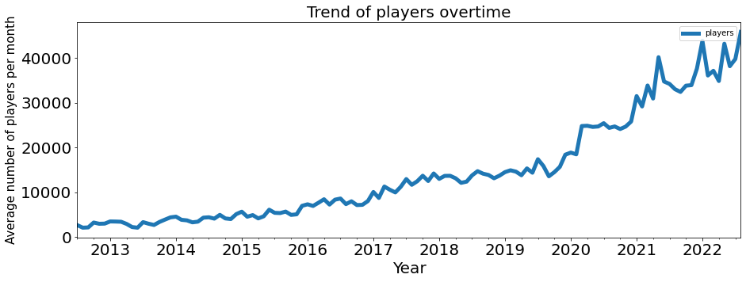

```python
players=apps.iloc[:,5:127].sum().T.reset_index()
players.columns=["month","players"]
players.month = pd.to_datetime(players.month)
players.set_index('month', inplace=True)
players.plot(figsize=(15,5), linewidth=5, fontsize=20)
plt.xlabel('Year', fontsize=20)
plt.ylabel('Average number of players per month', fontsize=15)
plt.title("Trend of players overtime",fontsize=20)
```

From the graph, we can see the trend that the gaming industry has obviously gained a lot more players over the years. However, It is not obvious whether COVID-19 has made an impact on it, especially since player count seems to have stagnated in 2020. To cut out noise, I shall do a rolling average

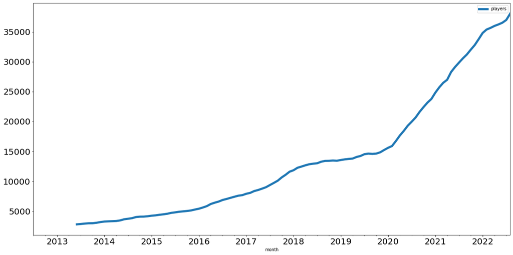

```python
players.rolling(12).mean().plot(figsize=(20,10), linewidth=5, fontsize=20)
```

Much better. It seems that the overall trend in 2020 spiked significantly. This could have a corrolation between COVID-19 which happened in 2020. To be sure, we can move on to the second question

Q2: I shall get the total number of cumulative measures per date, any measure that is a phase out measure is considered as a "negative measure"

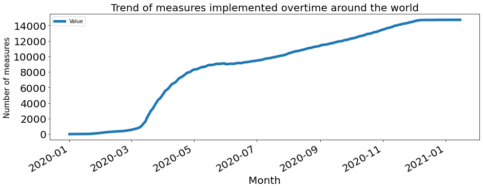

```python
cummeasure=measures.iloc[:,[3,5]].copy()
cummeasure.iloc[:,1] = pd.to_datetime(cummeasure.DATE_IMPLEMENTED)
cummeasure["Value"]=cummeasure.LOG_TYPE.str.match("Introduction / extension of measures")
cummeasure["Value"]=cummeasure["Value"].astype(int)
cummeasure["Value"]=cummeasure["Value"]*2-1
cummeasure = cummeasure.groupby('DATE_IMPLEMENTED').Value.sum()
cummeasure = cummeasure.groupby(cummeasure.index.time).cumsum().reset_index()
cummeasure.set_index('DATE_IMPLEMENTED', inplace=True)
cummeasure.plot(figsize=(15,5), linewidth=5, fontsize=20)
plt.xlabel('Month', fontsize=20)
plt.ylabel('Number of measures', fontsize=15)
plt.title("Trend of measures implemented overtime around the world",fontsize=20)
```

Plotting this against players during 2020

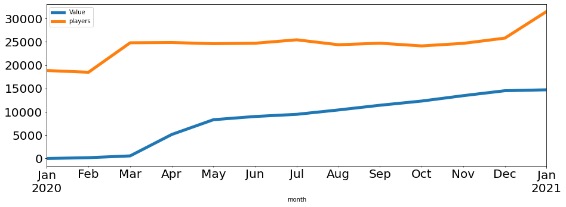

```python
players2020=players.reset_index()
players2020=players2020.loc[(players2020.month >= '2020-01-01')
                     & (players2020.month <= '2021-01-15')]
players2020.set_index('month', inplace=True)
timing=cummeasure.merge(players2020,right_index=True,left_index=True,how="right")
timing.plot(figsize=(15,5), linewidth=5, fontsize=20)
```

Number of players of computer game rose first, followed by the number of measures. We can plot a corrolation graph to see how closely corrolated they are.

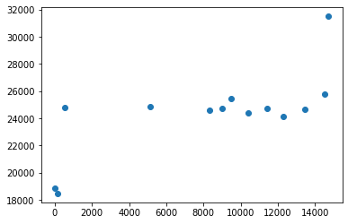

```python
y = timing['players']
x = timing['Value']
plt.scatter(x,y)
```

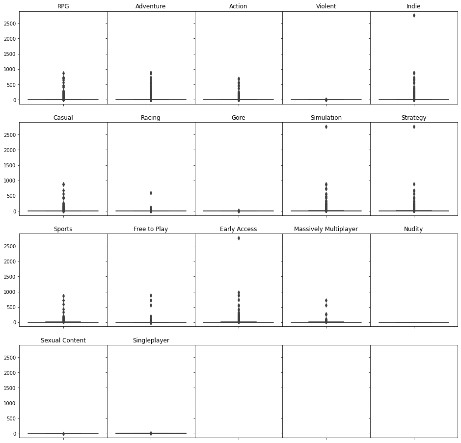

```python
nrow=4
ncol=5

# make a list of all dataframes
fig = plt.figure(figsize=(16,16))
gs = fig.add_gridspec(nrow, ncol, hspace=0.2, wspace=0)
axes = gs.subplots(sharex=True, sharey=True)
count=0

for r in range(nrow):
    for c in range(ncol):
        if count>16:
            break
        filtered=apps.loc[apps.iloc[:,count+127]==True].iloc[:,5:127].mean(axis=1)
        axes[r,c].set_xticks([])
        sns.boxplot(y=filtered,ax=axes[r,c]) #use ylim to standardize the y-axis
        axes[r,c].set_xticklabels([])
        axes[r,c].set_title (apps.columns[count+127]) #give every subplot a title
        count+=1
```

Firstly, this shows that a lot of games on steam do not actually get played, with pretty much at least 75% of games just being not played at all, with many outliers which gets a lot of players on average. I will plot a boxplot instead and get rid of all the games with lower than 100 players on average to get a clearer picture of how more popular games in each genre are doing.

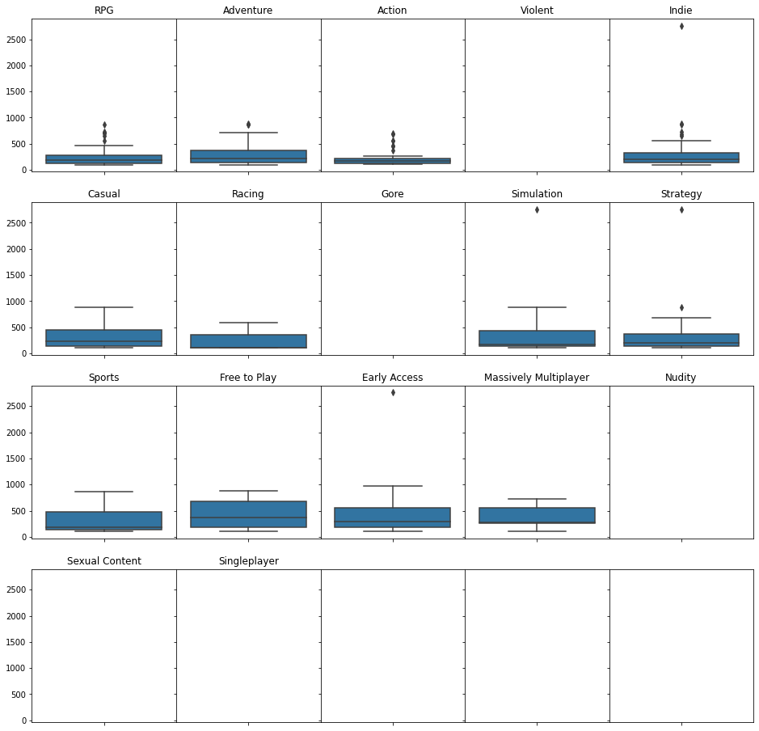

```python
nrow=4
ncol=5

# make a list of all dataframes
fig = plt.figure(figsize=(16,16))
gs = fig.add_gridspec(nrow, ncol, hspace=0.2, wspace=0)
axes = gs.subplots(sharex=True, sharey=True)
count=0

for r in range(nrow):
    for c in range(ncol):
        if count>16:
            break
        filtered=apps.loc[apps.iloc[:,count+127]==True].iloc[:,5:127].mean(axis=1)
        axes[r,c].set_xticks([])
        sns.boxplot(y=filtered.loc[filtered>100],ax=axes[r,c]) #use ylim to standardize the y-axis
        axes[r,c].set_xticklabels([])
        axes[r,c].set_title (apps.columns[count+127]) #give every subplot a title
        count+=1
```

As we can see, most games actually hover around the same range, from 100-1000 with some variation. There also some extreme outliers with 2500 players in some genres, like Indie, Simulation and Strategy, tho they are most likely pointing at the same data point as a game can have multiple genres. We should compare these box plots to the average player count during the 2020 pandemic

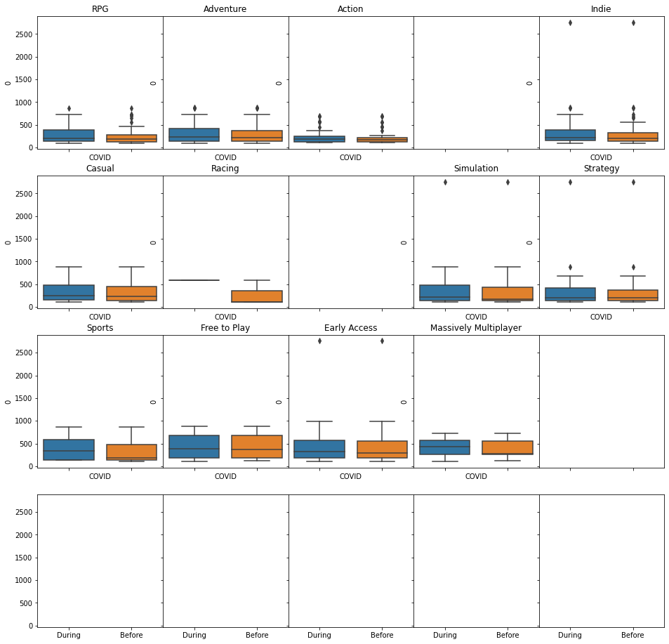

```python
nrow=4
ncol=5

# make a list of all dataframes
fig = plt.figure(figsize=(16,16))
gs = fig.add_gridspec(nrow, ncol, hspace=0.2, wspace=0)
axes = gs.subplots(sharex=True, sharey=True)
count=0

for r in range(nrow):
    for c in range(ncol):
        if count>16:
            break
        filtered=pd.DataFrame(apps.loc[apps.iloc[:,count+127]==True].iloc[:,100:127].mean(axis=1))
        filtered["COVID"]="During"
        filtered2=pd.DataFrame(apps.loc[apps.iloc[:,count+127]==True].iloc[:,5:127].mean(axis=1))
        filtered2["COVID"]="Before"
        filtered=pd.concat([filtered,filtered2],axis=0)
        if not filtered.loc[filtered.iloc[:,0]>100].iloc[:,0].empty:
            sns.boxplot(y=filtered.loc[filtered.iloc[:,0]>100].iloc[:,0],x=filtered.loc[filtered.iloc[:,0]>100].iloc[:,1],ax=axes[r,c]) #use ylim to standardize the y-axis
            axes[r,c].set_title (apps.columns[count+127]) #give every subplota title
        count+=1
```

As shown, most genres increased their medium player count, with sports seeing one of the biggest increase. In addition, it seemed that for RPG and Action games, it also brought some games into the spotlight, increasing their medium with much less outliers than before COVID-19. Let's see the proportion of them against each other prior to and and during COVID

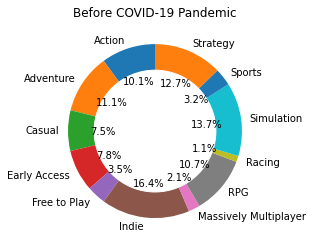

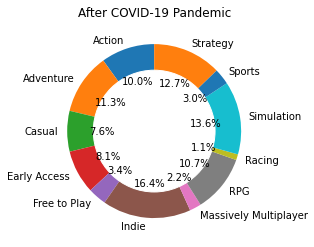

```python
count=0
total=pd.DataFrame()
for r in range(nrow):
    for c in range(ncol):
        if count>16:
            break
        filtered=pd.DataFrame(apps.loc[apps.iloc[:,count+127]==True].iloc[:,5:127].mean(axis=1))
        filtered["Genre"]=apps.columns[count+127]
        if filtered[0].sum()>1000:
            total=pd.concat([total,filtered],axis=0)
        count+=1
total.groupby("Genre")[0].sum()
plt.pie(
    total.groupby("Genre")[0].sum(),
    labels=total.groupby("Genre")[0].sum().index,
    shadow=False,
    startangle=90,
    autopct='%1.1f%%',
    )

my_circle=plt.Circle( (0,0), 0.7, color='white')
plt.title("Before COVID-19 Pandemic")
p=plt.gcf()
p.gca().add_artist(my_circle)

plt.show()

count=0
total=pd.DataFrame()
for r in range(nrow):
    for c in range(ncol):
        if count>16:
            break
        filtered=pd.DataFrame(apps.loc[apps.iloc[:,count+127]==True].iloc[:,100:127].mean(axis=1))
        filtered["Genre"]=apps.columns[count+127]
        if filtered[0].sum()>1000:
            total=pd.concat([total,filtered],axis=0)
        count+=1
total.groupby("Genre")[0].sum()
plt.pie(
    total.groupby("Genre")[0].sum(),
    labels=total.groupby("Genre")[0].sum().index,
    shadow=False,
    startangle=90,
    autopct='%1.1f%%',
    )

my_circle=plt.Circle( (0,0), 0.7, color='white')
p=plt.gcf()
p.gca().add_artist(my_circle)

plt.title("After COVID-19 Pandemic")


plt.show()
```

It seems the proportion has not changed much at all, let's look at the trend graphs to see if we can spot any patterns

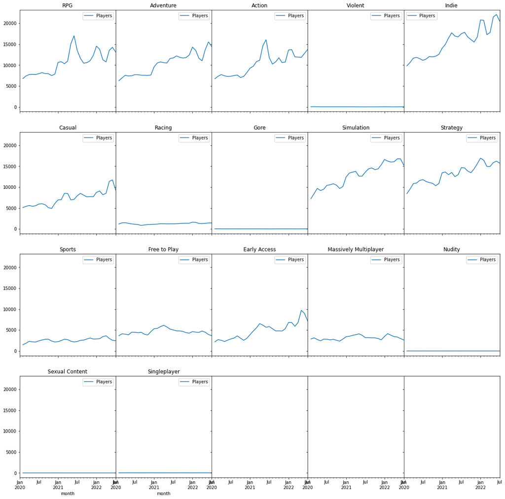

```python
nrow=4
ncol=5

# make a list of all dataframes
fig = plt.figure(figsize=(20,20))
gs = fig.add_gridspec(nrow, ncol, hspace=0.2, wspace=0)
axes = gs.subplots(sharex=True, sharey=True)
count=0

for r in range(nrow):
    for c in range(ncol):
        if count>16:
            break
        filtered=apps.loc[apps.iloc[:,count+127]==True].iloc[:,5:127].sum().reset_index()
        filtered.columns=["month","Players"]
        filtered.month = pd.to_datetime(filtered.month)
        filtered=filtered.loc[(filtered.month >= '2020-01-01')
                         & (filtered.month <= '2022-07-15')]
        filtered.set_index('month', inplace=True)
        filtered.rolling(2).mean().plot(ax=axes[r,c]) #use ylim to standardize the y-axis
        axes[r,c].set_title (apps.columns[count+127]) #give every subplot a title
        count+=1
```

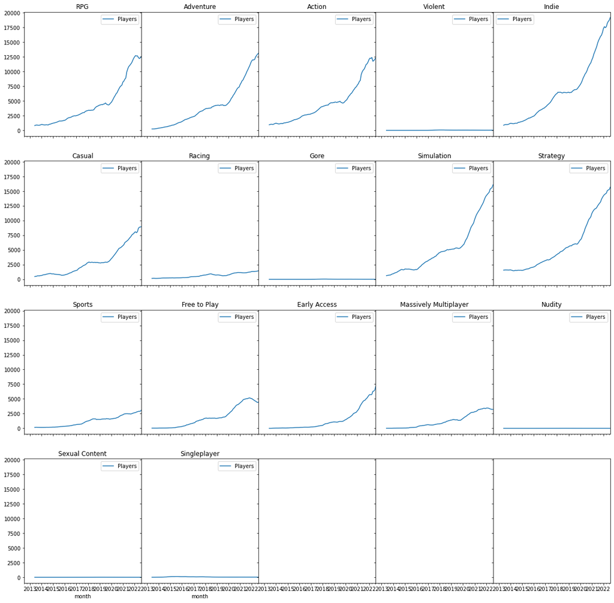

```python
nrow=4
ncol=5

# make a list of all dataframes
fig = plt.figure(figsize=(20,20))
gs = fig.add_gridspec(nrow, ncol, hspace=0.2, wspace=0)
axes = gs.subplots(sharex=True, sharey=True)
count=0

for r in range(nrow):
    for c in range(ncol):
        if count>16:
            break
        filtered=apps.loc[apps.iloc[:,count+127]==True].iloc[:,5:127].sum().reset_index()
        filtered.columns=["month","Players"]
        filtered.month = pd.to_datetime(filtered.month)
        filtered.set_index('month', inplace=True)
        filtered.rolling(12).mean().plot(ax=axes[r,c]) #use ylim to standardize the y-axis
        axes[r,c].set_title (apps.columns[count+127]) #give every subplot a title
        count+=1
```

It seems that some of the genres follows a trend, with a spike in December and January 2021, it also seems that some genres increased from February to March, which is consistent with what we've seen previously. Some genres are also too unpopular to view any trends, they shall be viewed seperately. It can be seen that RPGs, Adventure, Action, Indie and Strategy has massively increased over the course of 2020, with a dip in 2021 for RPG and Action. though an increase can still be seen. These genres seem to have done really well over the course of the pandemic. In addition, most of the genres has been seeing a huge increase since 2020. It is also interesting to note that RPG and Action has very similar trend graphs

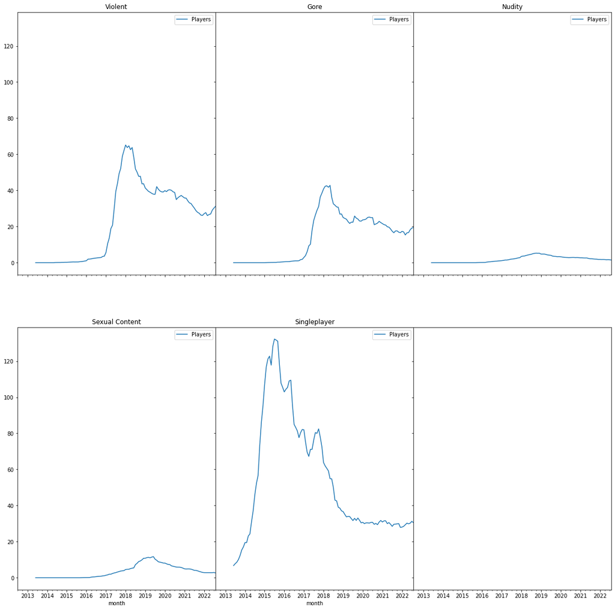

```python
nrow=2
ncol=3
lists=[3,7,14,15,16]

# make a list of all dataframes
fig = plt.figure(figsize=(20,20))
gs = fig.add_gridspec(nrow, ncol, hspace=0.2, wspace=0)
axes = gs.subplots(sharex=True, sharey=True)
count=0

for r in range(nrow):
    for c in range(ncol):
        if count>4:
            break
        filtered=apps.loc[apps.iloc[:,lists[count]+127]==True].iloc[:,5:127].sum().reset_index()
        filtered.columns=["month","Players"]
        filtered.month = pd.to_datetime(filtered.month)
        filtered.set_index('month', inplace=True)
        filtered.rolling(12).mean().plot(ax=axes[r,c]) #use ylim to standardize the y-axis
        axes[r,c].set_title (apps.columns[lists[count]+127]) #give every subplot a title
        count+=1
```

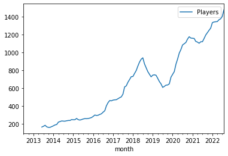

```python
filtered=apps.loc[apps.iloc[:,133]==True].iloc[:,5:127].sum().reset_index()
filtered.columns=["month","Players"]
filtered.month = pd.to_datetime(filtered.month)
filtered.set_index('month', inplace=True)
filtered.rolling(12).mean().plot() #use ylim to standardize the y-axis
```

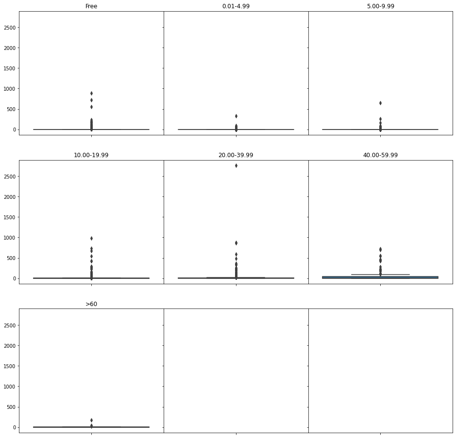

```python
nrow=3
ncol=3

# make a list of all dataframes
bins=["Free","0.01-4.99","5.00-9.99","10.00-19.99","20.00-39.99","40.00-59.99",">60"]
fig = plt.figure(figsize=(16,16))
gs = fig.add_gridspec(nrow, ncol, hspace=0.2, wspace=0)
axes = gs.subplots(sharex=True, sharey=True)
count=0

for r in range(nrow):
    for c in range(ncol):
        if count>6:
            break
        filtered=apps.loc[apps["PriceBin"]==bins[count]].iloc[:,5:127].mean(axis=1)
        axes[r,c].set_xticks([])
        sns.boxplot(y=filtered,ax=axes[r,c]) #use ylim to standardize the y-axis
        axes[r,c].set_xticklabels([])
        axes[r,c].set_title (bins[count]) #give every subplot a title
        count+=1
```

Like with genre, this is not a reliable way to see the trend of games in terms of player counts. Let's filter out the games that aren't played

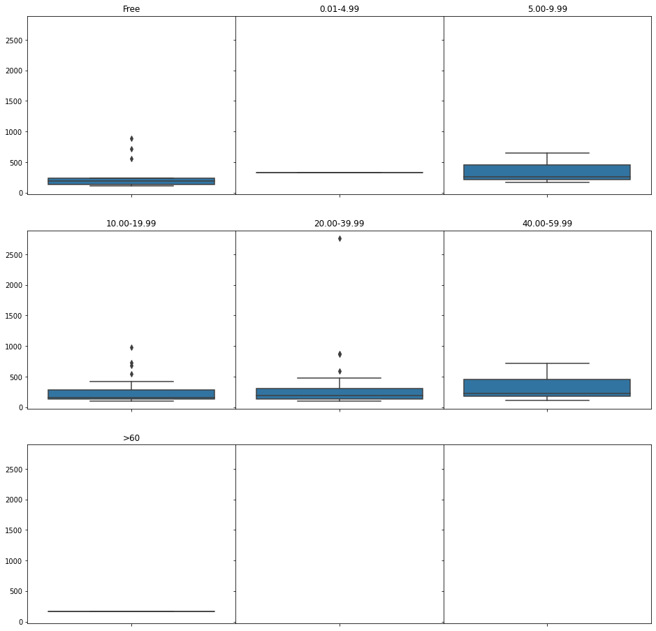

```python
nrow=3
ncol=3

# make a list of all dataframes
bins=["Free","0.01-4.99","5.00-9.99","10.00-19.99","20.00-39.99","40.00-59.99",">60"]
fig = plt.figure(figsize=(16,16))
gs = fig.add_gridspec(nrow, ncol, hspace=0.2, wspace=0)
axes = gs.subplots(sharex=True, sharey=True)
count=0

for r in range(nrow):
    for c in range(ncol):
        if count>6:
            break
        filtered=apps.loc[apps["PriceBin"]==bins[count]].iloc[:,5:127].mean(axis=1)
        axes[r,c].set_xticks([])
        sns.boxplot(y=filtered.loc[filtered>100],ax=axes[r,c]) #use ylim to standardize the y-axis
        axes[r,c].set_xticklabels([])
        axes[r,c].set_title (bins[count]) #give every subplot a title
        count+=1
```

Interestingly, 40-59.99 has a a lot more games with people playing them, with one of the highest mediums, with $5-10 games also close behind, let's compare them pre-covid to post-covid now

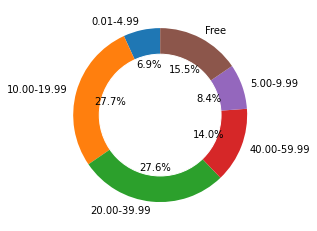

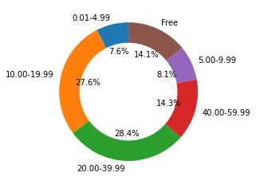

```python
count=0
total=pd.DataFrame()
bins=["Free","0.01-4.99","5.00-9.99","10.00-19.99","20.00-39.99","40.00-59.99",">60"]
for r in range(nrow):
    for c in range(ncol):
        if count>6:
            break
        filtered=pd.DataFrame(apps.loc[apps["PriceBin"]==bins[count]].iloc[:,5:127].mean(axis=1))
        filtered["Price"]=bins[count]
        if filtered[0].sum()>1000:
            total=pd.concat([total,filtered],axis=0)
        count+=1
total.groupby("Price")[0].sum()
plt.pie(
    total.groupby("Price")[0].sum(),
    labels=total.groupby("Price")[0].sum().index,
    shadow=False,
    startangle=90,
    autopct='%1.1f%%',
    )

my_circle=plt.Circle( (0,0), 0.7, color='white')
p=plt.gcf()
p.gca().add_artist(my_circle)

plt.show()

count=0
total=pd.DataFrame()
for r in range(nrow):
    for c in range(ncol):
        if count>6:
            break
        filtered=pd.DataFrame(apps.loc[apps["PriceBin"]==bins[count]].iloc[:,100:127].mean(axis=1))
        filtered["Price"]=bins[count]
        if filtered[0].sum()>1000:
            total=pd.concat([total,filtered],axis=0)
        count+=1
total.groupby("Price")[0].sum()
plt.pie(
    total.groupby("Price")[0].sum(),
    labels=total.groupby("Price")[0].sum().index,
    shadow=False,
    startangle=90,
    autopct='%1.1f%%',
    )

my_circle=plt.Circle( (0,0), 0.7, color='white')
p=plt.gcf()
p.gca().add_artist(my_circle)

plt.show()
```

Nothing changed too much from here. However, it is worth noting that paid games has a bigger pie after COVID-19. However, it is not significant of a decrease for free games. Let's look at the trends now

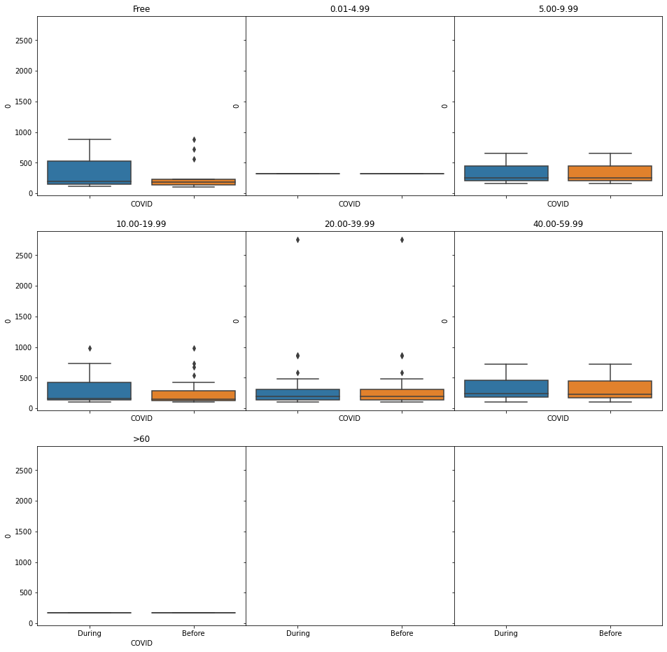

```python
nrow=3
ncol=3

# make a list of all dataframes
bins=["Free","0.01-4.99","5.00-9.99","10.00-19.99","20.00-39.99","40.00-59.99",">60"]
fig = plt.figure(figsize=(16,16))
gs = fig.add_gridspec(nrow, ncol, hspace=0.2, wspace=0)
axes = gs.subplots(sharex=True, sharey=True)
count=0

for r in range(nrow):
    for c in range(ncol):
        if count>6:
            break
        filtered=pd.DataFrame(apps.loc[apps["PriceBin"]==bins[count]].iloc[:,100:127].mean(axis=1))
        filtered["COVID"]="During"
        filtered2=pd.DataFrame(apps.loc[apps["PriceBin"]==bins[count]].iloc[:,5:127].mean(axis=1))
        filtered2["COVID"]="Before"
        filtered=pd.concat([filtered,filtered2],axis=0)
        if not filtered.loc[filtered.iloc[:,0]>100].iloc[:,0].empty:
            sns.boxplot(y=filtered.loc[filtered.iloc[:,0]>100].iloc[:,0],x=filtered.loc[filtered.iloc[:,0]>100].iloc[:,1],ax=axes[r,c]) #use ylim to standardize the y-axis
            axes[r,c].set_title (bins[count]) #give every subplot a title
        count+=1
```

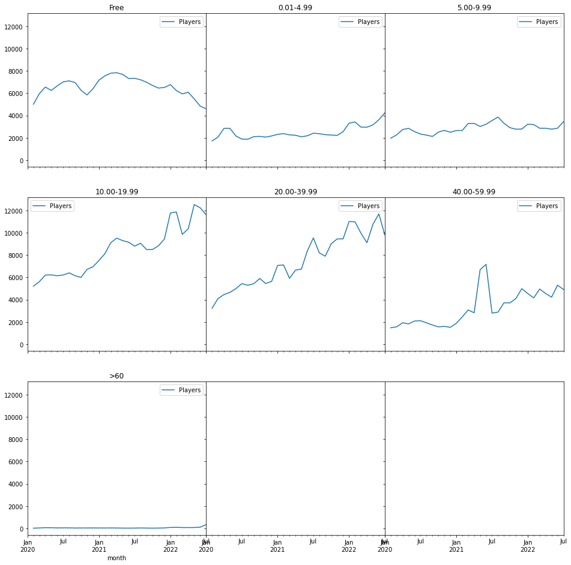

```python
nrow=3
ncol=3


# make a list of all dataframes
bins=["Free","0.01-4.99","5.00-9.99","10.00-19.99","20.00-39.99","40.00-59.99",">60"]
fig = plt.figure(figsize=(16,16))
gs = fig.add_gridspec(nrow, ncol, hspace=0.2, wspace=0)
axes = gs.subplots(sharex=True, sharey=True)
count=0

for r in range(nrow):
    for c in range(ncol):
        if count>6:
            break
        filtered=apps.loc[apps["PriceBin"]==bins[count]].iloc[:,5:127].sum().reset_index()
        filtered.columns=["month","Players"]
        filtered.month = pd.to_datetime(filtered.month)
        filtered=filtered.loc[(filtered.month >= '2020-01-01')
                         & (filtered.month <= '2022-07-15')]
        filtered.set_index('month', inplace=True)
        filtered.rolling(2).mean().plot(ax=axes[r,c]) #use ylim to standardize the y-axis
        axes[r,c].set_title (bins[count]) #give every subplot a title
        count+=1
```

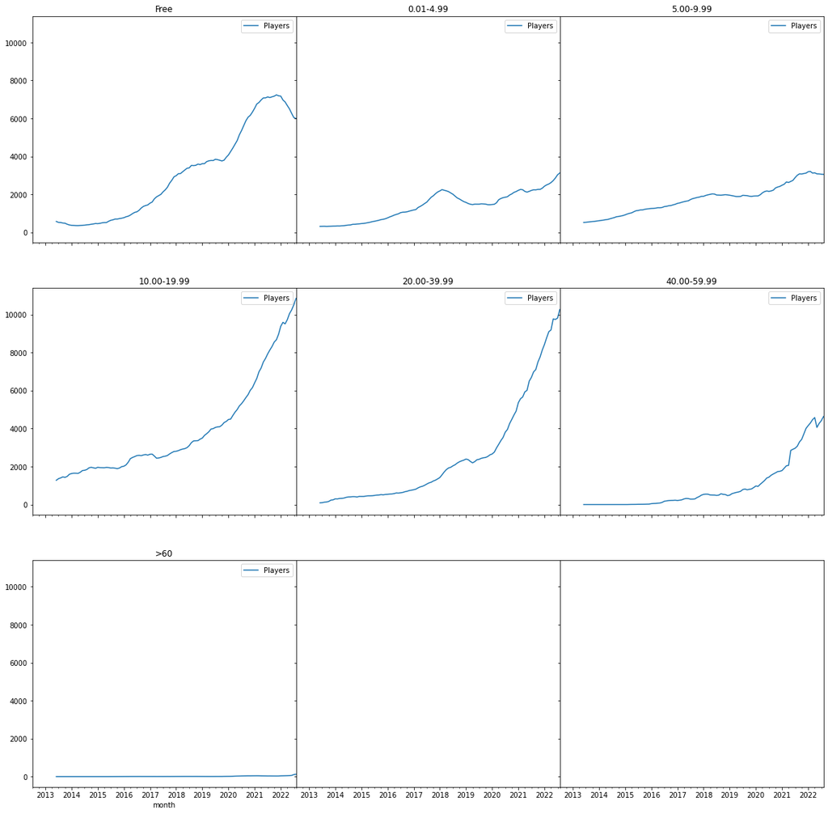

```python
nrow=3
ncol=3

# make a list of all dataframes
fig = plt.figure(figsize=(20,20))
gs = fig.add_gridspec(nrow, ncol, hspace=0.2, wspace=0)
axes = gs.subplots(sharex=True, sharey=True)
count=0

for r in range(nrow):
    for c in range(ncol):
        if count>6:
            break
        filtered=apps.loc[apps["PriceBin"]==bins[count]].iloc[:,5:127].sum().reset_index()
        filtered.columns=["month","Players"]
        filtered.month = pd.to_datetime(filtered.month)
        filtered.set_index('month', inplace=True)
        filtered.rolling(12).mean().plot(ax=axes[r,c]) #use ylim to standardize the y-axis
        axes[r,c].set_title (bins[count]) #give every subplot a title
        count+=1
```

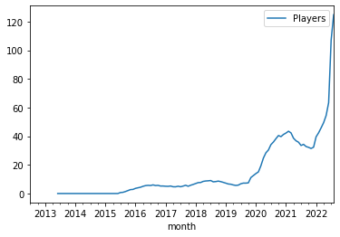

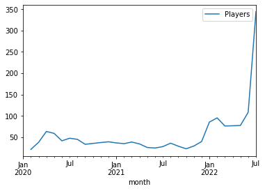

```python
filtered=apps.loc[apps["PriceBin"]==">60"].iloc[:,5:127].sum().reset_index()
filtered.columns=["month","Players"]
filtered.month = pd.to_datetime(filtered.month)
filtered.set_index('month', inplace=True)
filtered.rolling(12).mean().plot() #use ylim to standardize the y-axis
filtered=filtered.reset_index()
filtered=filtered.loc[(filtered.month >= '2020-01-01')
                         & (filtered.month <= '2022-07-15')]
filtered.set_index('month', inplace=True)
filtered.rolling(2).mean().plot() #use ylim to standardize the y-axis
```

It is noteworthing that 60 dollars games have fewer than 100 players playing for the majority of the years, which means the data could be easily skewed. Nevertheless, it has spiked a lot after the pandemic. In addition, Free and the cheaper(0.01 - 39.99) games immediately increase in the year 2020. It is also significant that 40.00 - 59.99 increased in 2021, not in 2020 when the pandemic hit.

# Results Findings & Conclusion

For each research question, summarize in 2-3 visualizations which will answer the question. Intrepret the results accordingly and give your observation and conclusion. The visualizations should be well presented (apply what you have learnt in Chapter 9 on data communication). The plots shown here could be an enhanced version of the EDA plots, or presented in another format.

Q1

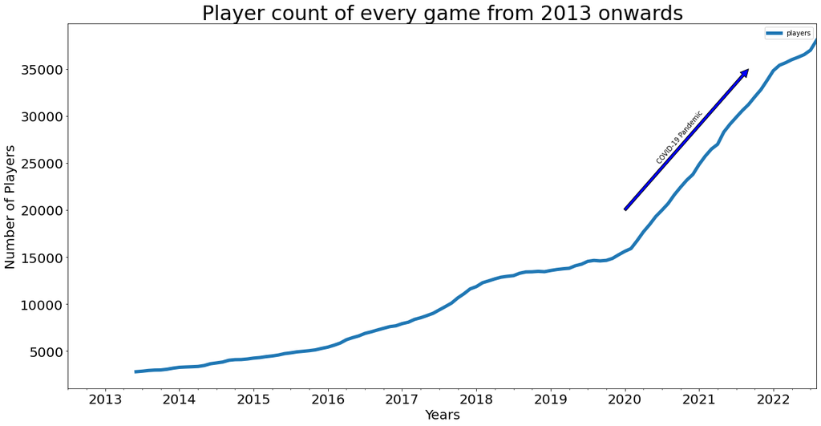

```python
ax=players.rolling(12).mean().plot(figsize=(20,10), linewidth=5, fontsize=20)
plt.annotate("",xy=(620,35000),xytext=(600,20000),
             arrowprops=dict(facecolor='blue'))
plt.annotate("COVID-19 Pandemic",xy=(605,25000),rotation=50)

plt.title('Player count of every game from 2013 onwards',fontsize=30)
plt.ylabel('Number of Players',fontsize=20)
plt.xlabel('Years',fontsize=20)
```

It is very clear that from the graph, in 2020 the number of players playing video games has increased significantly. This could corrolate to the COVID-19 pandemic, which we will investigate in further questions.

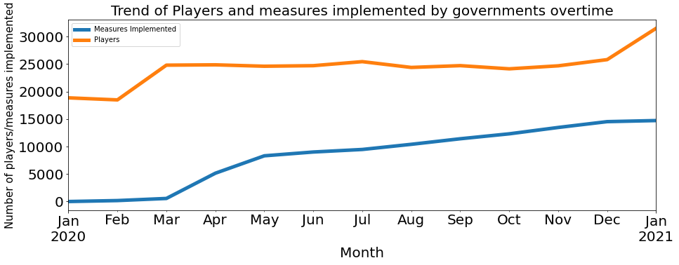

```python
cummeasure=measures.iloc[:,[3,5]].copy()
cummeasure.iloc[:,1] = pd.to_datetime(cummeasure.DATE_IMPLEMENTED)
cummeasure["Measures Implemented"]=cummeasure.LOG_TYPE.str.match("Introduction / extension of measures")
cummeasure["Measures Implemented"]=cummeasure["Measures Implemented"].astype(int)
cummeasure["Measures Implemented"]=cummeasure["Measures Implemented"]*2-1
cummeasure = cummeasure.groupby('DATE_IMPLEMENTED')["Measures Implemented"].sum()
cummeasure = cummeasure.groupby(cummeasure.index.time).cumsum().reset_index()
cummeasure.set_index('DATE_IMPLEMENTED', inplace=True)
players2020=players.reset_index()
players2020=players2020.loc[(players2020.month >= '2020-01-01')
                     & (players2020.month <= '2021-01-15')]
players2020.set_index('month', inplace=True)
players2020.columns=["Players"]
timing=cummeasure.merge(players2020,right_index=True,left_index=True,how="right")
timing.plot(figsize=(15,5), linewidth=5, fontsize=20)
plt.xlabel('Month', fontsize=20)
plt.ylabel('Number of players/measures implemented', fontsize=15)
plt.title("Trend of Players and measures implemented by governments overtime",fontsize=20)
```

This trend does show players and measures implemented are corrolated. However, the unexpected part is that player count increased first, before measures implemented increases.I do have a few reasons on why the trend is as such, with players increasing first before measures.

1. Government response towards COVID-19 was slow, resulting in people trying to protect themselves, staying at home.
2. People may have also felt the stress of a coming pandemic, resulting in them playing more games as well

Q3

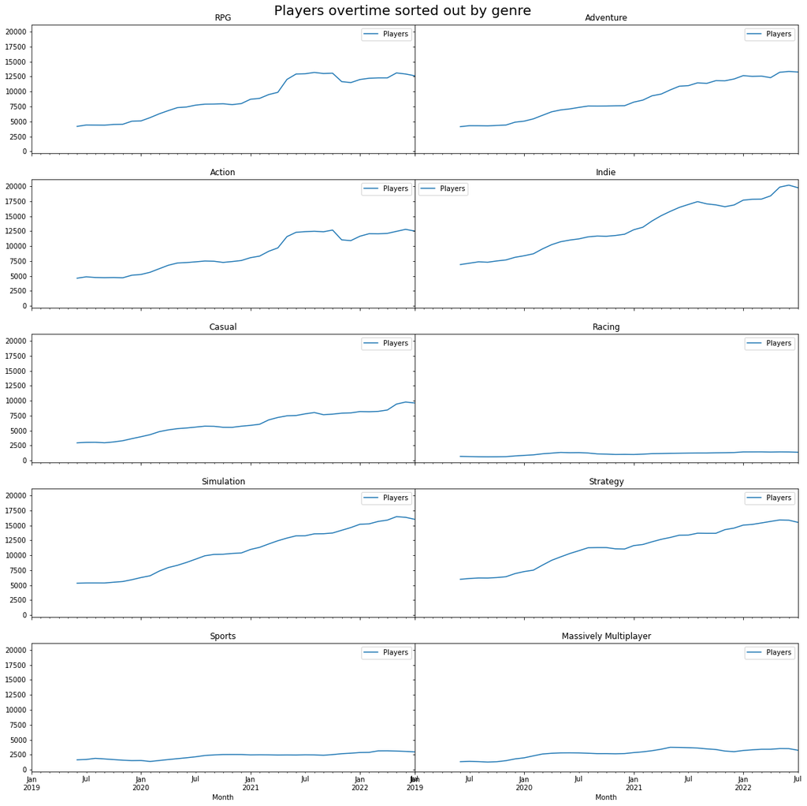

```python
nrow=5
ncol=2
lists=[3,7,11,12,14,15,16]

# make a list of all dataframes
fig = plt.figure(figsize=(20,20))
gs = fig.add_gridspec(nrow, ncol, hspace=0.2, wspace=0)
axes = gs.subplots(sharex=True, sharey=True)
count=0

for r in range(nrow):
    for c in range(ncol):
        while count in lists:
            count+=1
        if count>16:
            break
        filtered=apps.loc[apps.iloc[:,count+127]==True].iloc[:,5:127].sum().reset_index()
        filtered.columns=["Month","Players"]
        filtered.Month = pd.to_datetime(filtered.Month)
        filtered=filtered.loc[(filtered.Month >= '2019-01-01')
                         & (filtered.Month <= '2022-07-15')]
        filtered.set_index('Month', inplace=True)
        filtered.rolling(6).mean().plot(ax=axes[r,c]) #use ylim to standardize the y-axis
        axes[r,c].set_title (apps.columns[count+127]) #give every subplot a title
        count+=1
plt.suptitle("Players overtime sorted out by genre",fontsize=20,y=0.9)
```

During the pandemic, RPGs, Adventure, Action, Casual, Simulation and Strategy game rose sharply. Meanwhile, Racing, Sports, Massively Multiplayer had little increase over the pandemic.

The games that rose sharply either gave people a way to escape into a another reality(RPGs, Adventure, Action, Simulation), allow them to play whenever they felt like it(Casual Games) or allow them to build skill and build self-esteem in Strategy Games.

Massively Multiplayer, despite the lack of human contact over the pandemic, did not seem to increase much at all. This could be due to the fact Massively Multiplayer requires a lot of time investment into the game, allowing people to constantly socialise with others, which may not be what people have wanted during the pandemic.

Instead, the data suggests that people were more stress than they were isolated and just needed a way to relieve it.

Q4

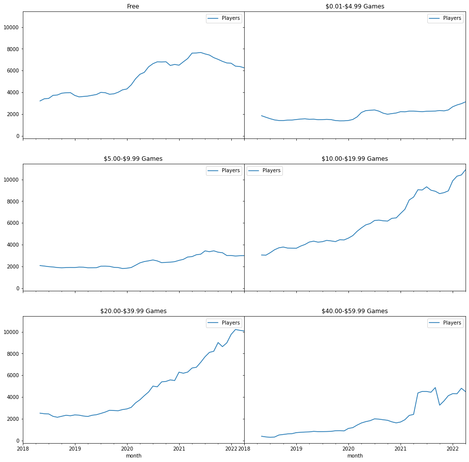

```python
nrow=3
ncol=2


# make a list of all dataframes
bins=["Free","0.01-4.99","5.00-9.99","10.00-19.99","20.00-39.99","40.00-59.99"]
labelbins=["Free","\$0.01-\$4.99 Games","\$5.00-\$9.99 Games","\$10.00-\$19.99 Games","\$20.00-\$39.99 Games","\$40.00-\$59.99 Games" ]
fig = plt.figure(figsize=(16,16))
gs = fig.add_gridspec(nrow, ncol, hspace=0.2, wspace=0)
axes = gs.subplots(sharex=True, sharey=True)
count=0

for r in range(nrow):
    for c in range(ncol):
        if count>5:
            break
        filtered=apps.loc[apps["PriceBin"]==bins[count]].iloc[:,5:127].sum().reset_index()
        filtered.columns=["month","Players"]
        filtered.month = pd.to_datetime(filtered.month)
        filtered=filtered.loc[(filtered.month >= '2018-01-01')
                         & (filtered.month <= '2022-04-15')]
        filtered.set_index('month', inplace=True)
        filtered.rolling(5).mean().plot(ax=axes[r,c]) #use ylim to standardize the y-axis
        axes[r,c].set_title (labelbins[count]) #give every subplot a title
        count+=1
```

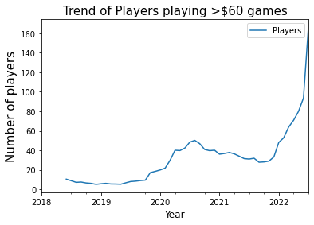

```python
filtered=apps.loc[apps["PriceBin"]==">60"].iloc[:,5:127].sum().reset_index()
filtered.columns=["month","Players"]
filtered.month = pd.to_datetime(filtered.month)
filtered=filtered.loc[(filtered.month >= '2018-01-01')
                         & (filtered.month <= '2022-07-15')]
filtered.set_index('month', inplace=True)
filtered.rolling(6).mean().plot() #use ylim to standardize the y-axis
plt.xlabel('Year', fontsize=12)
plt.ylabel('Number of players', fontsize=15)
plt.title("Trend of Players playing >$60 games",fontsize=15)
```

It is clear that player count has increased drastically for >$60 games. This could be due to the fact that people are more willing to spend money on games, after having been more acquanted with them over COVID-19. In addition, Free games have also visibly increased in 2020, showing that it is a stepping stone for people who have never played games before. As the pandemic occurs, the paid games increases rapidly, while the free games remains relatively the same. Moreover, 2 years after the pandemic, the amount of free games played slightly decreases, supporting my point on how people transfer over to paid games.

# Recommendations or Further Works

State any recommendations, improvements or further works.

### The data clearly shows that gaming did increase drastically in 2020. There is a corrolation with measures implemented in 2020, albeit it being an unexpected one, which does show that COVID-19 had a part to play in gaming's industry growth.

### In addition, we can also conclude that people were looking for a way to destress during this period, resulting in more RPGs, Adventure, Casual and Strategy games being played by people.

### Finally, we found that free games are the perfect landing platform for new gamers, and as a result free games benefitted heavily from the masses of new people playing online games, with anyone who enjoyed them then paying games.

### I would've liked to work with more data outside of player counts. Data such as when games were bought and sold, etc would've allowed me to conduct more varied anaylsis, seeing how the difference between games being bought and played changed over the course.

# References

Cite any references made, and links where you obtained the data. You may wish to read about how to use markdown in Jupyter notebook to make your report easier to read. https://www.ibm.com/docs/en/db2-event-store/2.0.0?topic=notebooks-markdown-jupyter-cheatsheet

1. https://www.acaps.org/covid-19-government-measures-dataset#:~:text=The%20COVID%2D19%20Government%20Measures,Social%20distancing
2. https://steamspy.com/api.php
3. https://steamcharts.com